# Fitting advanced N-mixture models

To increase the accuracy of this analysis, it is recommended to use a larger sample size of 20 sites per covariate. For instance, if you are using two covariates (elevation and forest cover) in your model, you should collect data from at least 40 sites. If the model includes too many covariates compared to the sample size, the parameters may not be estimated correctly and you may encounter NAs or seemingly irrational values. If you do not have a large enough sample size to include additional covariates in the model, it is suggested to exclude them to avoid incorrect results. In this analysis, we will be using a larger dataset called “hornbill2.csv” which contains data from 89 independent sites.

```r
#load data set
hornbill2 <- read.csv("hornbill2.csv", comment = "#", header = TRUE)
head(hornbill2)
```

```
##          y        x abundance.1 abundance.2 abundance.3 elevation forest water
## 1 223237.9 556645.2           0           0           0       940     37     5
## 2 219737.2 571650.7           1           1           1       530     35     5
## 3 296751.3 474114.8           0           0           0       352     36    31
## 4 282248.7 611665.5           0           0           0      1008     33     5
## 5 297751.5 574151.6           0           1           1       853     33     5
## 6 218737.1 513129.1           0           0           0       358     32     5
##   wind.1 wind.2 wind.3
## 1   23.2   22.5   23.4
## 2   23.4   23.1   23.3
## 3   22.9   24.0   22.1
## 4   23.8   24.3   24.5
## 5   21.5   23.5   23.8
## 6   20.2   23.6   24.0
```

```r
dim(hornbill2)
```

```
## [1] 89 11
```

```r
#load R package
install.packages("unmarked")
library(unmarked)
#re-organise input data
umf <- unmarkedFramePCount(
    y = hornbill2[, c("abundance.1", "abundance.2", "abundance.3")],
    siteCovs = data.frame(elevation = hornbill2$elevation,
                          forest = hornbill2$forest,
                          water = hornbill2$water),
    obsCovs = list(wind = hornbill2[, c("wind.1", "wind.2", "wind.3")])
)
summary(umf)
```

```
## unmarkedFrame Object
##
## 89 sites
## Maximum number of observations per site: 3
## Mean number of observations per site: 3
## Sites with at least one detection: 38
##
## Tabulation of y observations:
##   0   1   2   3   4   5   6   8  12
## 185  50  16   6   2   3   1   2   2
##
## Site-level covariates:
##    elevation          forest          water
##  Min.   :  94.0   Min.   : 0.00   Min.   : 5.00
##  1st Qu.: 395.0   1st Qu.:27.00   1st Qu.: 5.00
##  Median : 590.0   Median :33.00   Median : 5.00
##  Mean   : 629.9   Mean   :29.65   Mean   :10.89
##  3rd Qu.: 834.0   3rd Qu.:37.00   3rd Qu.: 5.00
##  Max.   :1667.0   Max.   :42.00   Max.   :69.00
##
## Observation-level covariates:
##       wind
##  Min.   :20.0
##  1st Qu.:21.4
##  Median :22.7
##  Mean   :22.6
##  3rd Qu.:23.8
##  Max.   :25.0
```

## Fitting N-mixture models with covariate effects

So far, you have created a basic model without considering any covariate effects. If you have a large number of sampling sites, you can try fitting N-mixture models that include covariate effects. This may provide a better explanation for variations in detection and abundance than simply assuming these values are constant.

One way to determine this is to create a set of models with different combinations of your covariates. However, generating 15 more models using every possible combination of site and observation covariates can be time-consuming, so it is recommended to carefully select candidate model sets based on your knowledge of the species and system rather than using this method.

The following models are written in unmarked notation.

```r
#constant detection and abundance
m1 <- pcount(~1 ~1, K = 100, data = umf)

#variations in detection (constant abundance)
m2 <- pcount(~wind ~1, K = 100, data = umf)

#variations in abundance (constant detection)
m3 <- pcount(~1 ~elevation, K = 100, data = umf)
m4 <- pcount(~1 ~forest, K = 100, data = umf)
m5 <- pcount(~1 ~water, K = 100, data = umf)
m6 <- pcount(~1 ~elevation+forest, K = 100, data = umf)
m7 <- pcount(~1 ~elevation+water, K = 100, data = umf)
m8 <- pcount(~1 ~forest+water, K = 100, data = umf)
m9 <- pcount(~1 ~elevation+forest+water, K = 100, data = umf)

#variations in both detection and abundance
m10 <- pcount(~wind ~elevation, K = 100, data = umf)
m11 <- pcount(~wind ~forest, K = 100, data = umf)
m12 <- pcount(~wind ~water, K = 100, data = umf)
m13 <- pcount(~wind ~elevation+forest, K = 100, data = umf)
m14 <- pcount(~wind ~elevation+water, K = 100, data = umf)
m15 <- pcount(~wind ~forest+water, K = 100, data = umf)
m16 <- pcount(~wind ~elevation+forest+water, K = 100, data = umf)
```

## Choosing ‘best’ model

In practice, it is often difficult to know which model is the most accurate representation of the data. You may have different hypotheses about what factors influence abundance and detection, which can result in a large number of competing models.

To compare these models, you can use the Akaike Information Criterion (AIC), a single number score that helps determine which model is the most likely to be the best fit for a given data set. AIC scores are relative, meaning that they are only useful when compared to other AIC scores for the same data. A lower AIC score indicates a better fit.

You can use the aictab() function from the AICcmodavg package to calculate AIC for a list of models and compare them. In this example, a quick examination of the AIC scores shows that model m6 is considered the best fit for the data. Model m6 includes elevation and forest cover as predictors of abundance.

```r
library(AICcmodavg)
fit.list <- aictab(c(m1, m2, m3, m4, m5, m6, m7, m8, m9, m10, m11, m12, m13, m14, m15, m16))
fit.list
```

```
##
## Model selection based on AICc:
##
##       K   AICc Delta_AICc AICcWt Cum.Wt      LL
## Mod6  4 375.18       0.00      1      1 -183.35
## Mod7  4 407.60      32.43      0      1 -199.56
## Mod14 5 410.98      35.81      0      1 -200.13
## Mod3  3 417.89      42.71      0      1 -205.80
## Mod9  5 433.05      57.87      0      1 -211.16
## Mod16 6 435.56      60.39      0      1 -211.27
## Mod15 5 437.52      62.35      0      1 -213.40
## Mod11 4 440.55      65.38      0      1 -216.04
## Mod8  4 454.52      79.35      0      1 -223.02
## Mod4  3 457.79      82.62      0      1 -225.75
## Mod13 5 469.16      93.98      0      1 -229.22
## Mod12 4 472.11      96.94      0      1 -231.82
## Mod10 4 485.57     110.40      0      1 -238.55
## Mod5  3 489.98     114.81      0      1 -241.85
## Mod2  3 492.26     117.09      0      1 -242.99
## Mod1  2 510.22     135.05      0      1 -253.04
```

## Making predictions

One of the main advantages of modeling is that it allows you to make predictions about expected abundance and detection when given new data. Now that you have identified the top model (the model with the most support), you can use it to make inferences and predictions. You can use the model to understand what it is telling you about the data.

### Single point

For example, you may want to ask: “What is the average abundance of a sampling site at 1000m above sea level with 50% forest cover?” To predict a single data point, you can use the exp() function to calculate abundance and plogis() function to calculate probability. If you are using a model with covariates like m6, you will need to include the covariate effects and the value of interest in your calculation. An example of this is shown below.

```r
#what is the expected abundance of a sampling site if it was located at 1000m
#above sea level and covered by 50% forest?
predict.abundance <- exp(m6@opt$par[1] +            #abundance intercept
                         m6@opt$par[2]*1000 +       #elevation
                         m6@opt$par[3]*50)          #forest cover
predict.abundance
```

```
## [1] 7.676183
```

```r
#what is the detection probability of a sampling site?
predict.detection <- plogis(m6@opt$par[4])          #detection intercept
predict.detection*100
```

```
## [1] 57.92527
```

### 2D surface

You can also visualize predictions of abundance over a range of covariate values by creating plots. To generate predictions for a range of data points, you can use the predict() function. This function returns the predictions along with standard errors and confidence intervals. This information can be used to create plots.

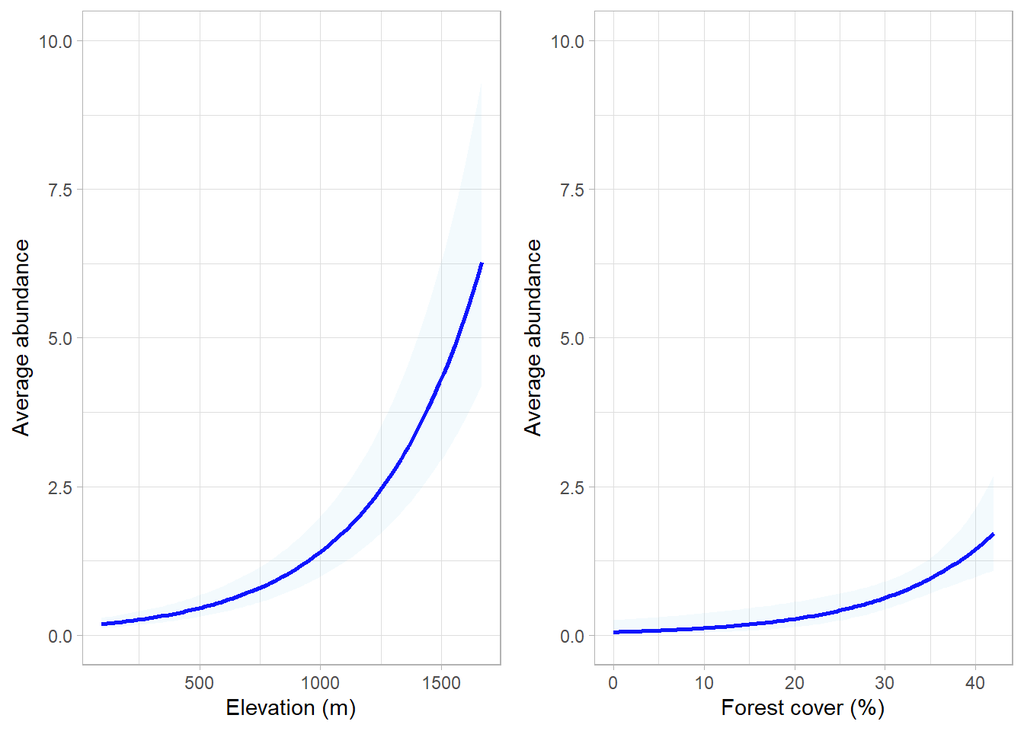

```r
##load graphics packages
library(ggplot2)
library(cowplot)

##predict abundance across elevation range
#prepare new data
pred.elev <- data.frame(
    elevation = seq(min(umf@siteCovs$elevation, na.rm = TRUE),  # min elevation cover
                    max(umf@siteCovs$elevation, na.rm = TRUE),  # max elevation cover
                    length = 100),                              # number of points in range
    forest = rep(mean(umf@siteCovs$forest), length = 100),      # average forest cover
    water = rep(mean(umf@siteCovs$water), length = 100))        # average water
#predict abundance with new data
pred.elevation <- predict(
    m6,                         # model to predict from
    type = "state",             # sub model to predict from
    newdata = pred.elev,        # new values to use for predictions
    append = TRUE)              # add new data to prediction data frame
#setup elevation plot
gpred.elevation <- ggplot() +
    geom_line(aes(x = pred.elevation$elevation, y = pred.elevation$Predicted), color = "blue", size = 1) +
    geom_ribbon(aes(x = pred.elevation$elevation, ymin = pred.elevation$lower,
                ymax = pred.elevation$upper), fill = "sky blue", alpha = 0.1) +
    ylab("Average abundance") +
    xlab("Elevation (m)") +
    ylim(0, 10) +
    theme_light()

##predict abundance across forest cover range
#prepare new data
pred.fore <- data.frame(
    forest = seq(min(umf@siteCovs$forest, na.rm = TRUE),            # min forest cover
                 max(umf@siteCovs$forest, na.rm = TRUE),            # max forest cover
                 length = 100),                                     # number of points in range
    elevation = rep(mean(umf@siteCovs$elevation), length = 100),    # average elevation
    water = rep(mean(umf@siteCovs$water), length = 100))            # average water
#predict count with new data
pred.forest <- predict(
    m6,                         # model to predict from
    type = "state",             # sub model to predict from
    newdata = pred.fore,        # new values to use for predictions
    append = TRUE)              # add newdata to prediction data frame
#setup elevation plot
gpred.forest <- ggplot() +
    geom_line(aes(x = pred.forest$forest, y = pred.forest$Predicted), color = "blue", size = 1) +
    geom_ribbon(aes(x = pred.forest$forest, ymin = pred.forest$lower,
                ymax = pred.forest$upper), fill = "sky blue", alpha = 0.1) +
    ylab("Average abundance") +
    xlab("Forest cover (%)") +
    ylim(0, 10) +
    theme_light()

#plot detection predictions side-by-side
plot_grid(gpred.elevation, gpred.forest, nrow = 1)
```

### 3D surface

You can also create maps to visualize predictions of abundance. To make predictions over a surface, you will need spatial forest cover data for the entire FMU (Forest Management Unit). This data can be obtained from websites such as Global Forest Watch and [USGS](https://www.usgs.gov/centers/eros/science/usgs-eros-archive-digital-elevation-shuttle-radar-topography-mission-srtm-1), though you may need to manipulate it before using it for analysis. To make predictions, you will need to load data with longitude and latitude values for each site or pixel, as well as a column for the covariate value (each row represents one site or pixel).

```r
study_area <- read.csv("study_area.csv", header = TRUE)
head(study_area)
```

```
##          y        x elevation forest water
## 1 372765.2 484618.6       573     48     5
## 2 372265.1 484118.4       502     47     5
## 3 372265.1 484618.6       761     48     5
## 4 372265.1 499124.0       942     42     5
## 5 372265.1 499624.2       688     43     5
## 6 372265.1 500124.4       524     34     5
```

```r
dim(study_area)
```

```
## [1] 78233     5
```

```r
siteCovs.map <- data.frame(elevation = study_area$elevation,
                           forest = study_area$forest)
head(siteCovs.map)
```

```
##   elevation forest
## 1       573     48
## 2       502     47
## 3       761     48
## 4       942     42
## 5       688     43
## 6       524     34
```

You will need to use the predict() function to estimate abundance, standard errors, and confidence intervals for each site/pixel.

```r
predict.abundance <- predict(
    m6,                             # model to predict from
    type = "state",                 # sub model to predict from
    newdata = siteCovs.map,         # new values to use for predictions
    append = TRUE)                  # add newdata to prediction data frame
#save predictions
save(predict.abundance, file = "predict.abundance.RData")
```

Setup elevation map

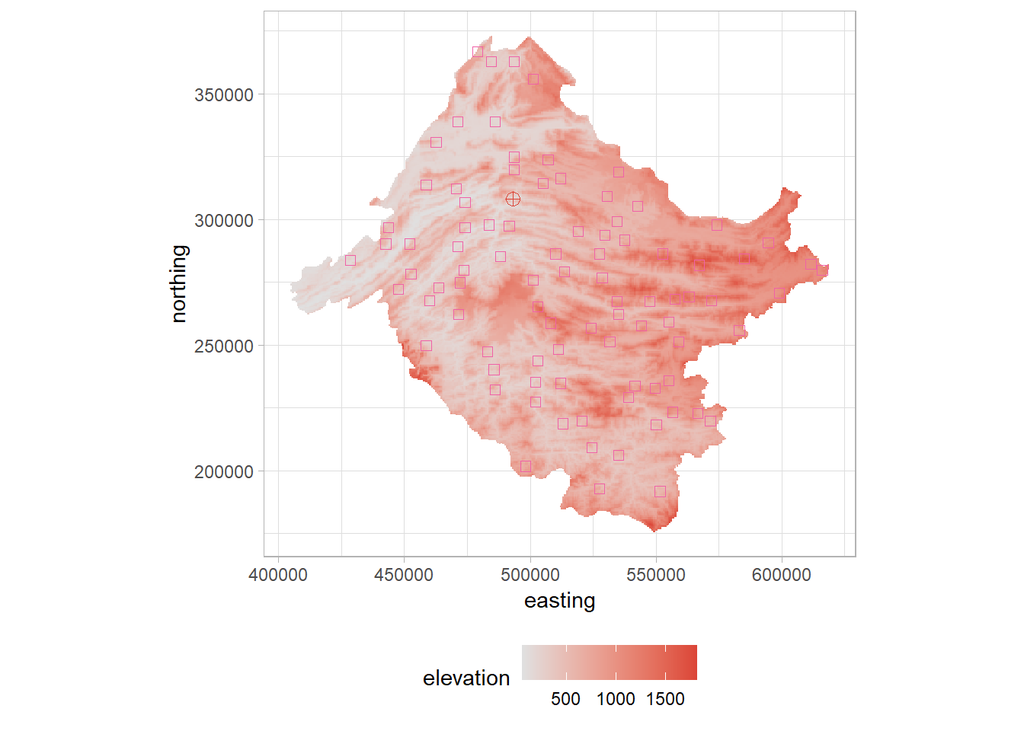

```r
elevation.map <- ggplot() +
    geom_tile(data = study_area, aes(x = x, y = y, fill = elevation)) +
        scale_fill_gradient(low = "grey88", high = "#DB4437") +
    xlab("easting") +
    ylab("northing") +
    coord_fixed() +
    theme_light() +
    theme(plot.title = element_text(hjust = 0.5)) +
    theme(legend.position = "bottom") +
    geom_point(aes(x = hornbill2$x, y = hornbill2$y), colour = "#F062A7", shape = 0, alpha = 1, size = 2) +
    geom_point(aes(x = 493092, y = 308119), colour = "#DB4437", shape = 10, size = 3)
elevation.map
```

Setup forest cover map

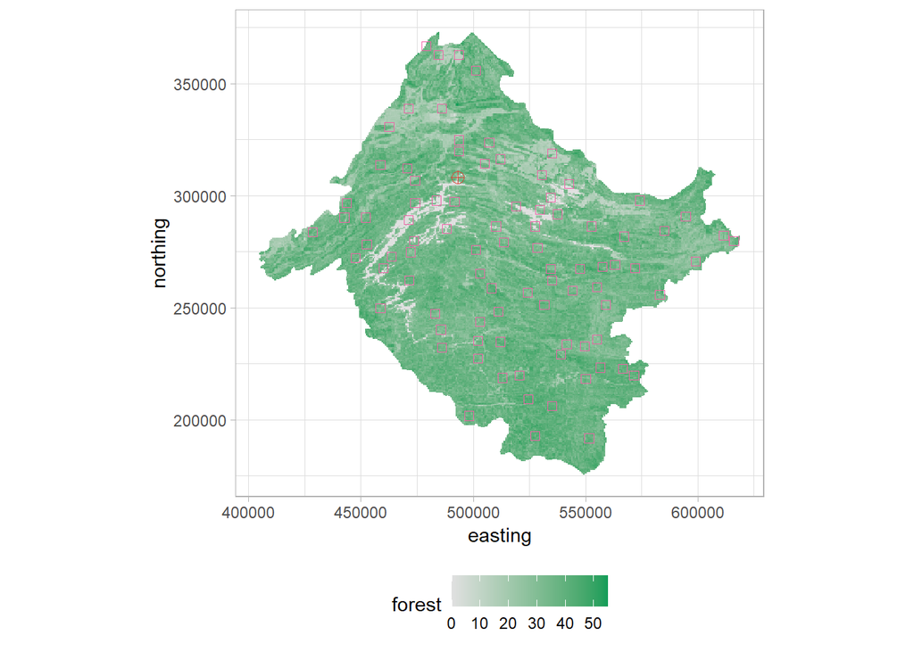

```r
forest.map <- ggplot() +
    geom_tile(data = study_area, aes(x = x, y = y, fill = forest)) +
        scale_fill_gradient(low = "grey88", high = "#0F9D58") +
    xlab("easting") +
    ylab("northing") +
    coord_fixed() +
    theme_light() +
    theme(plot.title = element_text(hjust = 0.5)) +
    theme(legend.position = "bottom") +
    geom_point(aes(x = hornbill2$x, y = hornbill2$y), colour = "#F062A7", shape = 0, alpha = 1, size = 2) +
    geom_point(aes(x = 493092, y = 308119), colour = "#DB4437", shape = 10, size = 3)
forest.map
```

Setup predicted abundance map

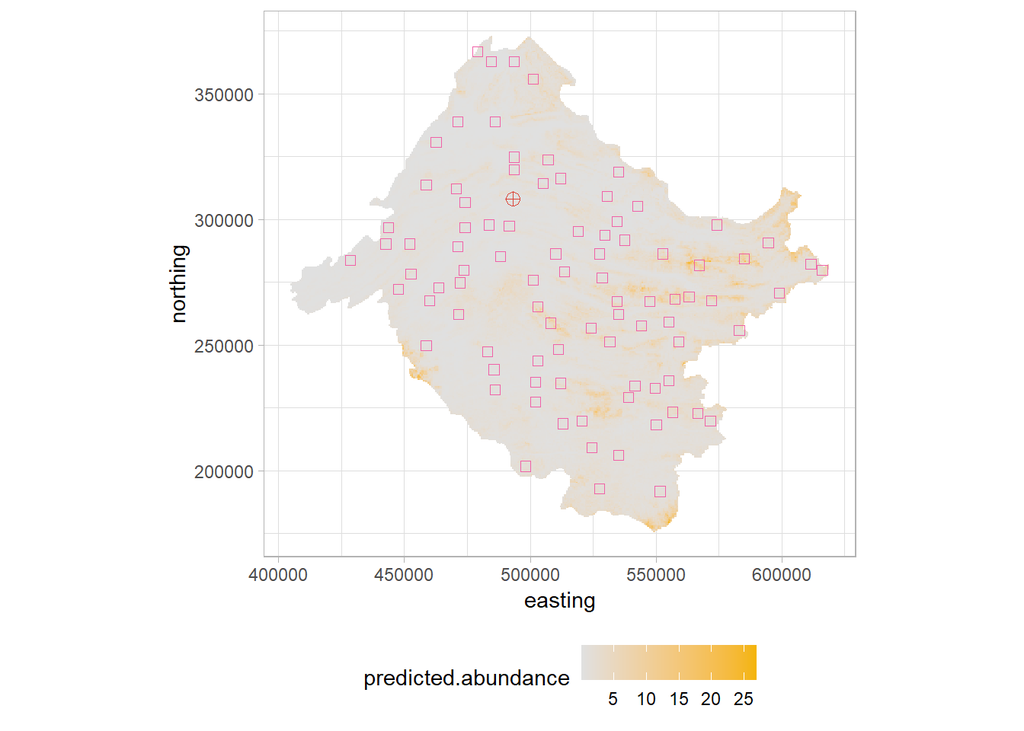

```r
#load prediction output
load("predict.abundance.RData")
#copy columns Predict and SE into study area
study_area$predicted.abundance <- predict.abundance$Predicted
study_area$uncertainty <- predict.abundance$SE

abundance.predicted <- ggplot() +
    geom_tile(data = study_area, aes(x = x, y = y, fill = predicted.abundance)) +
        scale_fill_gradient(low = "grey88", high = "#F4B400") +
    xlab("easting") +
    ylab("northing") +
    coord_fixed() +
    theme_light() +
    theme(plot.title = element_text(hjust = 0.5)) +
    theme(legend.position = "bottom") +
    geom_point(aes(x = hornbill2$x, y = hornbill2$y), colour = "#F062A7", shape = 0, alpha = 1, size = 2) +
    geom_point(aes(x = 493092, y = 308119), colour = "#DB4437", shape = 10, size = 3)
abundance.predicted
```

Setup abundance’s standard error (uncertainty) map

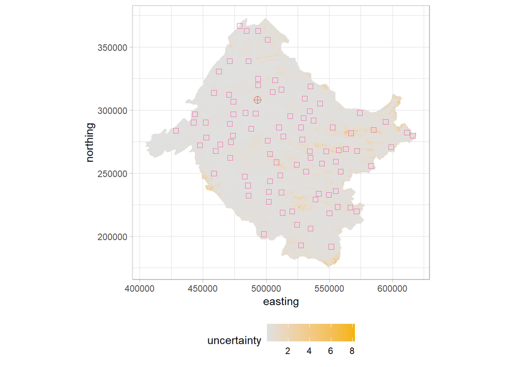

```r
abundance.uncertainty <- ggplot() +
    geom_tile(data = study_area, aes(x = x, y = y, fill = uncertainty)) +
        scale_fill_gradient(low = "grey88", high = "#F4B400") +
    xlab("easting") +
    ylab("northing") +
    coord_fixed() +
    theme_light() +
    theme(plot.title = element_text(hjust = 0.5)) +
    theme(legend.position = "bottom") +
    geom_point(aes(x = hornbill2$x, y = hornbill2$y), colour = "#F062A7", shape = 0, alpha = 1, size = 2) +
    geom_point(aes(x = 493092, y = 308119), colour = "#DB4437", shape = 10, size = 3)
abundance.uncertainty
```